The most important homework, good thing we'ev got a free extension on it!

# Mth 416 - HW7

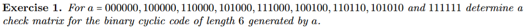

We only have one definition of binary cyclic codes, and they are typically generated by a single codeword, not many.

I'll use the smallest monic polynomial $1$ to represent the canonical generator of $a$: $g=100000$. Note that each of these codewords are in the column space of $I_6$, so the cyclic code generated by the canonical generator also generates all of $a$ and all of $\mathbb{F}_2$, $\langle g \rangle = I_6$

According to 7.1.33, we can find the check matrix using $gt = 1t = x^6-1$, giving us

$$ n = 6 \\ k = \text{deg } t = 6 \\ m = \text{deg } g = 0 \\ $$

Since the check matrix is $m\times n$, this means there is no check matrix (it is $0\times 6$), which makes sense since all of $\mathbb{F}_2$ is in the binary cyclic code, no binary vectors are sent to $\vec 0$

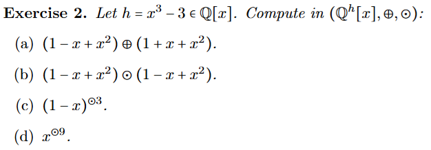

(a) $(1-x+x^2) \oplus (1+x+x^2)$  
Note that we are not in $\mathbb{F}_2$

$$ (1-x+x^2) + (1+x+x^2) = 2+2x+2x^2 $$ This is degree less than 3, so it is the final result

(b) $(1 - x + x^2) \odot (1-x+x^2)$

$$ f \odot g = \overline{fg} \\ (1-x+x^2)(1-x+x^2)=1-2x+3x^2-2x^3+x^4 \\ $$ Lets find the remainder. Unfortunately this format doesn't have any latex packages $$ \begin{matrix} &&&&&x&-2\\ x^3-3 &|& x^4&-2x^3&+3x^2&-2x&+1 \\ && -x^4& && +3x \\ &\rightarrow & & -2x^3 &+3x^2 & +x & +1 \\ &&& +2x^3& && - 6 \\ &\rightarrow & & 3x^2 && +x & -5 \end{matrix} $$ Thus the remainder is $3x^2 + x-5$, which is our result.

(c) $(1-x)^{\odot 3}$

Using 7.1.12d, we know this is equivalent to $\overline{(1-x)^3}$

$$ \overline{(1-x)^3} = \overline{1-3x+3x^2 -x^3}= -2-3x+3x^2\\ $$

(d) $x^{\odot 9} = \overline{x^9} = 27$

Completed using a long division calculator

$$ x^9 = (x^6+3x^3+9)(x^3-3)+27 $$

We'll make use of lemma 7.1.17, note that $x^{12}+1 = x^{12}-1$ in $\mathbb{F}_2$

$$ f=x^4 + x^{10} + x^{3*12+1}+x^{8*12+4}+x^{101*12+1} \\ =x^4 + x^{10} + x + x^4 + x \\= x^{10} $$

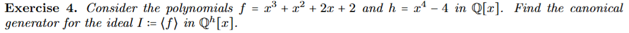

$$ I = \langle f \rangle = \left\{g \odot f\ |\ g \in \mathbb{Q}[x]\right\} \\ $$ Since the canonical generator must divide $h$ according to lemma 7.1.30 and must be lower order than $h$, let's find the factors of $h$ in $\mathbb{Q}[x]$.

$$ x^4 -4 = (x^2-2)(x^2+2) $$ One of these is the canonical generator of $I$.

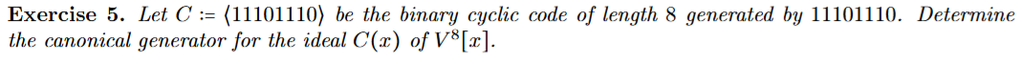

The cyclic shift of $11101110$ with the lowest order is $11101110$, so this is the canonical generator

$g = 1 + x + x^2 + x^4 + x^5 + x^6$

This follows example 7.1.29

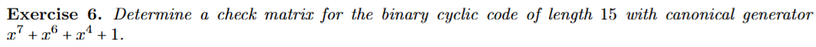

We will find $(x^{15}-1)/(x^7+x^6+x^4+1)$. We'll use an online calculator rather than doing long division.

$$ x^{15}+1 = (1+x^4+x^6+x^7+x^8)(1+x^4+x^6+x^7) $$

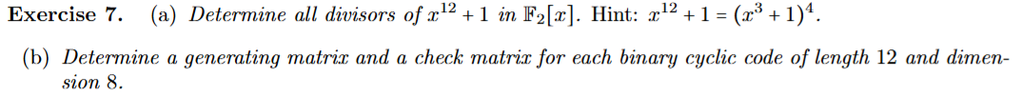

(b) skipped

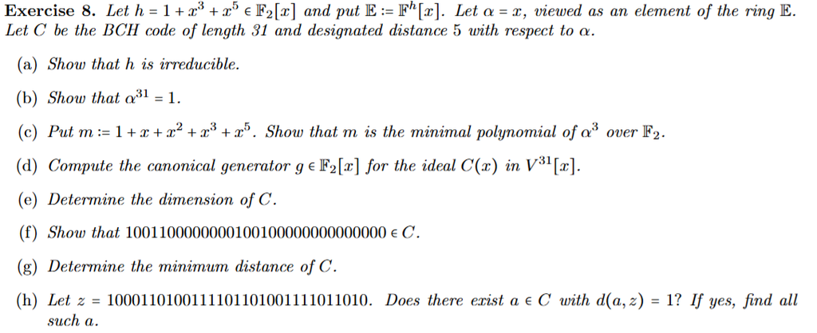

(a) Following example 7.2.5, we see that $h_n = h_5 = 1$, and since $h_0=1$ and an odd number of coefficients are equal to $1$, the polynomial has no roots and is irreductible.

Example 7.2.5:

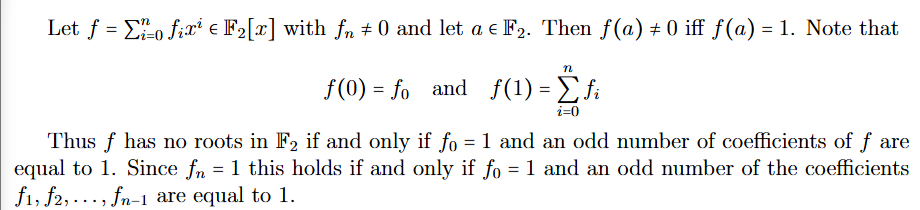

(b)

I'm sure there's a smart way to do this, but this is the best I've got $$ \alpha^6 = \overline{x^6} = x^4 + x = \alpha^4 + \alpha \\ %\alpha^{31} = \alpha \left(\alpha^4 + \alpha \right)^5 \alpha^7 = \alpha(\alpha^6) = \alpha^5 + \alpha^2 \\ \alpha^8 = \alpha(\alpha^7) = \alpha(\alpha^5 + \alpha^2) = \alpha^4 + \alpha + \alpha^3 \\ \alpha^9 = \alpha(\alpha^8) = \alpha^5 + \alpha^2 + \alpha^4 \\ \alpha^{10} = \alpha(\alpha^9) = (\alpha^4 + \alpha) + \alpha^3 + \alpha^5 \\ \alpha^{14} = (\alpha^7)^2 = \alpha^{10}+\alpha^4 = \alpha + \alpha^3 + \alpha^5 \\ $$ Using $\overline{x^5} = x^3 + 1$ we can simplify this down $$ \alpha^5 = \alpha^3 + 1 \\ \alpha + \alpha^3 + \alpha^5 = \alpha + \alpha^3 + \alpha^3 + 1 \alpha^{14} = \alpha + 1 \\ \alpha^{28} = \alpha^2 + 1 \\ \alpha^{31} = \alpha^{28}\alpha^3 = \alpha^5 + \alpha^3 = \alpha^3+\alpha^3+1=1 $$

(c) As described in 7.2.13, we want to show $m_{\alpha^3}^{\mathbb{F}}=m$.

First, check $m(\alpha^3)=0$

$$ \alpha^{15} = \alpha \alpha^{14} = \alpha^2 + \alpha^4 + \alpha^6 \\ m(\alpha^3) = 1 + \alpha^3 + \alpha^6 + \alpha^9 + \alpha^{15} \\ = 1 + \alpha^3 + \alpha^6 + (\alpha^5+\alpha^2+\alpha^4) + \alpha^2 + \alpha^4 + \alpha^6 \\ = 1 + \alpha^3 + \alpha^5\\ =0 $$

How to show this is the minimal polynomial? I don't know, especially since $h$ is irreductible.